# DATA 624: Homework 9

Andrew Bowen

2024-04-14

```r
library(tidyverse)
library(caret)
library(party)
library(randomForest)
library(gbm)
```

## Exercise 8.1

First, let’s recreate the data as they do in K&J

```r
library(mlbench)
set.seed(200)
simulated <- mlbench.friedman1(200, sd = 1)
simulated <- cbind(simulated$x, simulated$y)
simulated <- as.data.frame(simulated)
colnames(simulated)[ncol(simulated)] <- "y"
```

Now we can fit a random forest model to this dataset

```r
model1 <- randomForest(y ~ ., data = simulated, importance = TRUE,
ntree = 1000)

rfImp1 <- varImp(model1, scale = FALSE)

rfImp1
```

```
##         Overall
## V1   8.84289608
## V2   6.74508245
## V3   0.67830653
## V4   7.75934674
## V5   2.23628276
## V6   0.11429887
## V7   0.03724747
## V8  -0.05349642
## V9  -0.04495617
## V10  0.03863205
```

In terms of [variable importance](https://developers.google.com/machine-learning/decision-forests/variable-importances), the uninformative predictors are **not** being used by this model since they have some of the lower importance scores being returned.

```r
# Add correlated predictor
simulated$duplicate1 <- simulated$V1 + rnorm(200) * .1

# Fit separate random forest variable
model2 <- randomForest(y ~ ., data = simulated, importance = TRUE, ntree = 1000)

rfImp2 <- varImp(model2, scale = FALSE)

rfImp2
```

```
##                 Overall
## V1          6.008319352
## V2          6.308908170
## V3          0.571604465
## V4          7.187015958
## V5          2.131040245
## V6          0.211304611
## V7          0.025100355
## V8         -0.116980037
## V9         -0.003679481
## V10         0.024878337
## duplicate1  3.618101735
```

```r
# Add correlated predictor
simulated$duplicate2 <- simulated$V1 + rnorm(200) * .1

# Fit separate random forest variable
model3 <- randomForest(y ~ ., data = simulated, importance = TRUE, ntree = 1000)

rfImp3 <- varImp(model3, scale = FALSE)

rfImp3
```

```
##                Overall
## V1          4.80558793
## V2          6.24446517
## V3          0.44795506
## V4          7.36291029
## V5          2.28470921
## V6          0.25517978
## V7         -0.01177118
## V8         -0.06210267
## V9         -0.03187802
## V10         0.01454121
## duplicate1  2.49523514
## duplicate2  2.96244300
```

Here we see the importance for `V1` drops *again* with a second highly-correlated variable added.

```r
# Traing conditional inference tree
bagCtrl <- cforest_control(mtry = ncol(simulated) - 1)
baggedTree <- cforest(y ~ ., data = simulated, controls = bagCtrl)

varimp(baggedTree, conditional=TRUE)
```

```
##            V1            V2            V3            V4            V5
##  0.8201613769  4.3762948432  0.0002629888  5.9107383417  0.7994246735
##            V6            V7            V8            V9           V10
## -0.0090871345  0.0350111052 -0.0061488850 -0.0057271660  0.0026289503
##    duplicate1    duplicate2
##  0.0750520312  0.5457170569
```

We see a similar pattern here of the uninformative predictors (`V6 - V10`) don’t have strong importance in the conditional forest.

Let’s train on the same dataset with different tree types

```r
library(Cubist)
# Cubist model
predictors <- simulated %>% select(-c("y"))
cubistTuned <- cubist(predictors, simulated$y)

varImp(cubistTuned)
```

```
##            Overall
## V1              50
## V2              50
## V4              50
## V5              50
## V3               0
## V6               0
## V7               0
## V8               0
## V9               0
## V10              0
## duplicate1       0
## duplicate2       0
```

```r
# Boosted model
gbmGrid <- expand.grid(interaction.depth = seq(1, 5, by = 2),
                       n.trees = seq(100, 1000, by = 200),
                       shrinkage=c(0.1, 1.0),
                       n.minobsinnode=seq(1, 5, 2))
gbmTuned <- train(predictors, simulated$y, method = "gbm",
                  tuneGrid = gbmGrid,verbose = FALSE)


varImp(gbmTuned)
```

```
## gbm variable importance
##
##             Overall
## V4         100.0000
## V2          80.0712
## V1          53.9485
## V5          41.4160
## V3          31.9544
## duplicate1  25.8739
## duplicate2  24.6748
## V6           3.3719
## V7           2.5856
## V10          0.3880
## V9           0.2258
## V8           0.0000
```

In both cases we see the uninformative variables are **not** the most important for these models as well. In general, strong correlation will be pulled through in most models, regardless of algorithm changed

## Exercise 8.2

**Use a simulation to show tree bias with different granularities.**

```r
library(rpart)

# Re-sumlate data from Friedman
set.seed(12345)
simulated2 <- mlbench.friedman1(150, sd = 1)
simulated2 <- cbind(simulated2$x, simulated2$y)
simulated2 <- as.data.frame(simulated2)
colnames(simulated2)[ncol(simulated2)] <- "y"
```

```r
trainX <- simulated2 %>% dplyr::select(-c("y"))
trainY <- simulated2 $y
rpartTune <- train(trainX, trainY, method = "rpart2",
                   tuneLength = 10,
                   trControl = trainControl(method = "cv"))


varImp(rpartTune)
```

```
## rpart2 variable importance
##
##     Overall
## V1  100.000
## V2   83.378
## V5   82.766
## V3   70.448
## V4   40.410
## V7   27.813
## V10  21.770
## V8   15.978
## V9    8.287
## V6    0.000
```

## Exercise 8.3

The learning rate controls the contributions of weak learners, which could be dependent on factors that aren’t that important in predicting the outcome in the underlying data. In this case, the lower learning rate is less prone to overfitting to training data, since it will have contributions from a wider base of input variables, and not be as dependent on one fortunate training split.

## Exercise 8.7

Let’s use the same bit of code as we did before to set up our dataset:

```r
# Load chemical data
library(AppliedPredictiveModeling)
library(kernlab)
library(earth)
library(nnet)
library(ModelMetrics)
data("ChemicalManufacturingProcess")

chemical <- ChemicalManufacturingProcess
chemical_features <- chemical %>% dplyr::select(-c("Yield"))
```

We’ll impute this data the same way we did in HW7

```r
# Impute chemical yield data
imputed <- preProcess(chemical,
                       method = c("knnImpute"))

trans <- predict(imputed, chemical)
```

We’ll also set up a train-test split as well

```r
# Split into train and test splits
#use 75% of dataset as training set and 30% as test set
sample <- sample(c(TRUE, FALSE), nrow(trans), replace=TRUE, prob=c(0.8,0.2))
train  <- trans[sample, ]
train_yield <- train$Yield
train <- train %>%
  dplyr::select(-c("Yield"))
test <- trans[!sample, ]
test_yield <- test$Yield
test <- test  %>%
  dplyr::select(-c("Yield"))
```

First, we’ll train a gradient-boosting model via `gbm`

```r
gbmReg <- train(train, train_yield, method = "gbm",
       tuneGrid = gbmGrid, verbose = FALSE)
# Calculate RMSE of gradient boosted tree
gbmPred <- predict(gbmReg, test)
ModelMetrics::rmse(test_yield, gbmPred)
```

```
## [1] 0.5177699
```

Next, we can train a decision tree modelusing `rpart`

```r
rpartReg <- train(train, train_yield, method = "rpart2",
                  tuneLength = 10,
                  trControl = trainControl(method = "cv"))

# Calculate RMSE of gradient boosted tree
rpartPred <- predict(rpartReg, test)
ModelMetrics::rmse(test_yield, rpartPred)
```

```
## [1] 0.8569067
```

Alternatively, we can train a random Forest model as wel using the method employed in K&J

```r
library(randomForest)
rfModel <- randomForest(train, train_yield)



rfPred <- predict(rfModel, test)
ModelMetrics::rmse(test_yield, rfPred)
```

```
## [1] 0.6332397
```

Of our three models, our gradient-boosted and random forest perform the best in terms of RMSE. For this exercise, let’s gow with the random forest model

```r
varImp(rfModel)
```

```
##                            Overall
## BiologicalMaterial01    1.67902382
## BiologicalMaterial02    3.40147646
## BiologicalMaterial03    5.24196093
## BiologicalMaterial04    2.36760632
## BiologicalMaterial05    1.47799119
## BiologicalMaterial06    7.48916035
## BiologicalMaterial07    0.01027183
## BiologicalMaterial08    2.07018614
## BiologicalMaterial09    1.55990457
## BiologicalMaterial10    0.74444586
## BiologicalMaterial11    3.31591748
## BiologicalMaterial12    3.93808689
## ManufacturingProcess01  1.39752441
## ManufacturingProcess02  0.88357900
## ManufacturingProcess03  0.57250982
## ManufacturingProcess04  1.27432140
## ManufacturingProcess05  1.54684552
## ManufacturingProcess06  2.39323873
## ManufacturingProcess07  0.06210052
## ManufacturingProcess08  0.09496793
## ManufacturingProcess09  3.71617432
## ManufacturingProcess10  1.04094596
## ManufacturingProcess11  1.26345005
## ManufacturingProcess12  0.64178056
## ManufacturingProcess13 10.90914605
## ManufacturingProcess14  0.71845775
## ManufacturingProcess15  0.88028614
## ManufacturingProcess16  0.77796395
## ManufacturingProcess17  4.92705146
## ManufacturingProcess18  1.20971720
## ManufacturingProcess19  0.81927941
## ManufacturingProcess20  1.67848016
## ManufacturingProcess21  0.89207950
## ManufacturingProcess22  0.95389797
## ManufacturingProcess23  0.60696971
## ManufacturingProcess24  0.86889551
## ManufacturingProcess25  0.79445574
## ManufacturingProcess26  0.95388372
## ManufacturingProcess27  1.64539807
## ManufacturingProcess28  3.94965411
## ManufacturingProcess29  1.74582360
## ManufacturingProcess30  1.33879634
## ManufacturingProcess31  4.86413758
## ManufacturingProcess32 29.79971956
## ManufacturingProcess33  2.60481728
## ManufacturingProcess34  1.00719264
## ManufacturingProcess35  0.79415002
## ManufacturingProcess36  4.06508284
## ManufacturingProcess37  0.98999732
## ManufacturingProcess38  0.20530543
## ManufacturingProcess39  0.82221283
## ManufacturingProcess40  0.08066279
## ManufacturingProcess41  0.12686738
## ManufacturingProcess42  0.73164040
## ManufacturingProcess43  1.47097926
## ManufacturingProcess44  0.42830306
## ManufacturingProcess45  0.42059994
```

We can plot the tree trained via rpart using the `rpart.plot` functions

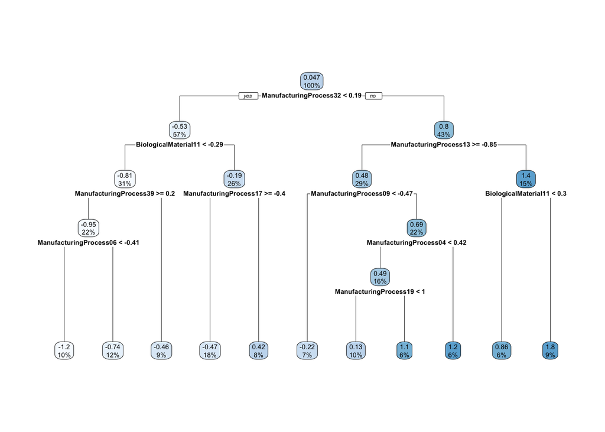

```r
library(rpart.plot)

rpartTree <- rpart(train_yield ~ ., data = cbind(train, train_yield))#, method = "reg")
rpart.plot(rpartTree)
```